# Analysis of Life Expectancy and Fertility Rate

Humphrey Afobhokhan

2024-01-24

# Introduction

This report examines the relationship between life expectancy and fertility rates across various regions for the years 1960 and 2020. Utilizing datasets provided by the World Bank and complemented by R vector data, we have created scatterplots that categorize countries by region, thereby allowing for a comparative analysis across two distinct time points in history.

```r
#import and read file
setwd("/Users/badboihy/Downloads/Visualizing & Analyzing Data with R - Methods & Tools/Assignments")
foo <-read.csv("Datset_IA.csv")
head(foo,5)
```

```
##           Country.Name Country.Code       Region Year Fertility.Rate
## 1                Aruba          ABW The Americas 1960          4.820
## 2          Afghanistan          AFG         Asia 1960          7.450
## 3               Angola          AGO       Africa 1960          7.379
## 4              Albania          ALB       Europe 1960          6.186
## 5 United Arab Emirates          ARE  Middle East 1960          6.928
```

```r
str(foo)
```

```
## 'data.frame':    374 obs. of  5 variables:
##  $ Country.Name  : chr  "Aruba" "Afghanistan" "Angola" "Albania" ...
##  $ Country.Code  : chr  "ABW" "AFG" "AGO" "ALB" ...
##  $ Region        : chr  "The Americas" "Asia" "Africa" "Europe" ...
##  $ Year          : int  1960 1960 1960 1960 1960 1960 1960 1960 1960 1960 ...
##  $ Fertility.Rate: num  4.82 7.45 7.38 6.19 6.93 ...
```

```r
#Changing integer into factor
factor(foo$Year)
```

[output not shown]

```r
foo$Year <- factor(foo$Year)
str(foo)
```

```
## 'data.frame':    374 obs. of  5 variables:
##  $ Country.Name  : chr  "Aruba" "Afghanistan" "Angola" "Albania" ...
##  $ Country.Code  : chr  "ABW" "AFG" "AGO" "ALB" ...
##  $ Region        : chr  "The Americas" "Asia" "Africa" "Europe" ...
##  $ Year          : Factor w/ 2 levels "1960","2020": 1 1 1 1 1 1 1 1 1 1 ...
##  $ Fertility.Rate: num  4.82 7.45 7.38 6.19 6.93 ...
```

```r
#exploring data set
nrow(foo)
```

```
## [1] 374
```

```r
ncol(foo)
```

```
## [1] 5
```

```r
tail(foo)
```

```
##         Country.Name Country.Code      Region Year Fertility.Rate
## 369            Samoa          WSM     Oceania 2020          4.147
## 370      Yemen, Rep.          YEM Middle East 2020          4.284
## 371     South Africa          ZAF      Africa 2020          2.387
## 372 Congo, Dem. Rep.          COD      Africa 2020          6.103
## 373           Zambia          ZMB      Africa 2020          5.429
## 374         Zimbabwe          ZWE      Africa 2020          3.977
```

```r
summary(foo)
```

```
##  Country.Name       Country.Code          Region            Year
##  Length:374         Length:374         Length:374         1960:187
##  Class :character   Class :character   Class :character   2020:187
##  Mode  :character   Mode  :character   Mode  :character
##
##
##
##  Fertility.Rate
##  Min.   :1.124
##  1st Qu.:2.243
##  Median :3.994
##  Mean   :4.191
##  3rd Qu.:6.252
##  Max.   :8.187
```

```r
# Creating Data Frame
foo_df <- data.frame(Country_Code, Life_Expectancy_At_Birth_1960, Life_Expectancy_At_Birth_2020)
head(foo_df)
```

```
##   Country_Code Life_Expectancy_At_Birth_1960 Life_Expectancy_At_Birth_2020
## 1          ABW                      65.56937                      75.32866
## 2          AFG                      32.32851                      60.02827
## 3          AGO                      32.98483                      51.86617
## 4          ALB                      62.25437                      77.53724
## 5          ARE                      52.24322                      77.19563
## 6          ARG                      65.21554                      75.98610
```

```r
#Renaming the columns in data frames
colnames(foo_df)<-c("Code", "Life_Expectancy_1960", "Life_Expectancy_2020")
head(foo_df)
```

```
##   Code Life_Expectancy_1960 Life_Expectancy_2020
## 1  ABW             65.56937             75.32866
## 2  AFG             32.32851             60.02827
## 3  AGO             32.98483             51.86617
## 4  ALB             62.25437             77.53724
## 5  ARE             52.24322             77.19563
## 6  ARG             65.21554             75.98610
```

```r
# Merging data frames
head(foo)
```

```
##           Country.Name Country.Code       Region Year Fertility.Rate
## 1                Aruba          ABW The Americas 1960          4.820
## 2          Afghanistan          AFG         Asia 1960          7.450
## 3               Angola          AGO       Africa 1960          7.379
## 4              Albania          ALB       Europe 1960          6.186
## 5 United Arab Emirates          ARE  Middle East 1960          6.928
## 6            Argentina          ARG The Americas 1960          3.109
```

```r
head(foo_df)
```

```
##   Code Life_Expectancy_1960 Life_Expectancy_2020
## 1  ABW             65.56937             75.32866
## 2  AFG             32.32851             60.02827
## 3  AGO             32.98483             51.86617
## 4  ALB             62.25437             77.53724
## 5  ARE             52.24322             77.19563
## 6  ARG             65.21554             75.98610
```

```r
foo_merged <- merge(foo, foo_df, by.x="Country.Code", by.y="Code")
head(foo_merged)
```

```
##   Country.Code Country.Name       Region Year Fertility.Rate
## 1          ABW        Aruba The Americas 1960          4.820
## 2          ABW        Aruba The Americas 2020          1.669
## 3          AFG  Afghanistan         Asia 2020          5.050
## 4          AFG  Afghanistan         Asia 1960          7.450
## 5          AGO       Angola       Africa 2020          6.165
## 6          AGO       Angola       Africa 1960          7.379
##   Life_Expectancy_1960 Life_Expectancy_2020
## 1             65.56937             75.32866
## 2             65.56937             75.32866
## 3             32.32851             60.02827
## 4             32.32851             60.02827
## 5             32.98483             51.86617
## 6             32.98483             51.86617
```

```r
tail(foo_merged)
```

```
##     Country.Code Country.Name Region Year Fertility.Rate Life_Expectancy_1960
## 369          ZAF South Africa Africa 2020          2.387             49.03629
## 370          ZAF South Africa Africa 1960          6.173             49.03629
## 371          ZMB       Zambia Africa 2020          5.429             45.10980
## 372          ZMB       Zambia Africa 1960          7.018             45.10980
## 373          ZWE     Zimbabwe Africa 1960          7.158             51.54246
## 374          ZWE     Zimbabwe Africa 2020          3.977             51.54246
##     Life_Expectancy_2020
## 369             56.73659
## 370             56.73659
## 371             59.23737
## 372             59.23737
## 373             55.63300
## 374             55.63300
```

```r
str(foo_merged)
```

```
## 'data.frame':    374 obs. of  7 variables:
##  $ Country.Code        : chr  "ABW" "ABW" "AFG" "AFG" ...
##  $ Country.Name        : chr  "Aruba" "Aruba" "Afghanistan" "Afghanistan" ...
##  $ Region              : chr  "The Americas" "The Americas" "Asia" "Asia" ...
##  $ Year                : Factor w/ 2 levels "1960","2020": 1 2 2 1 2 1 2 1 1 2 ...
##  $ Fertility.Rate      : num  4.82 1.67 5.05 7.45 6.17 ...
##  $ Life_Expectancy_1960: num  65.6 65.6 32.3 32.3 33 ...
##  $ Life_Expectancy_2020: num  75.3 75.3 60 60 51.9 ...
```

```r
#Locate missing data
complete.cases(foo_merged)
```

[output not shown]

```r
!complete.cases(foo_merged)
```

[output not shown]

[output cut: 17 more lines]

```r
foo_merged[!complete.cases(foo_merged),]
```

```
## [1] Country.Code         Country.Name         Region
## [4] Year                 Fertility.Rate       Life_Expectancy_1960
## [7] Life_Expectancy_2020
## <0 rows> (or 0-length row.names)
```

```r
# Analyzing NA Value
is.na(foo_merged$Country.Code)
```

[output not shown]

[output cut: 17 more lines]

```r
foo_merged[is.na(foo_merged$Country.Code),]
```

```
## [1] Country.Code         Country.Name         Region
## [4] Year                 Fertility.Rate       Life_Expectancy_1960
## [7] Life_Expectancy_2020
## <0 rows> (or 0-length row.names)
```

```r
is.na(foo_merged$Country.Name)
```

[output not shown]

[output cut: 17 more lines]

```r
foo_merged[is.na(foo_merged$Country.Name),]
```

```
## [1] Country.Code         Country.Name         Region
## [4] Year                 Fertility.Rate       Life_Expectancy_1960
## [7] Life_Expectancy_2020
## <0 rows> (or 0-length row.names)
```

```r
is.na(foo_merged$Region)
```

[output not shown]

[output cut: 17 more lines]

```r
foo_merged[is.na(foo_merged$Region),]
```

```
## [1] Country.Code         Country.Name         Region
## [4] Year                 Fertility.Rate       Life_Expectancy_1960
## [7] Life_Expectancy_2020
## <0 rows> (or 0-length row.names)
```

```r
is.na(foo_merged$Year)
```

[output not shown]

[output cut: 17 more lines]

```r
foo_merged[is.na(foo_merged$Year),]
```

```
## [1] Country.Code         Country.Name         Region
## [4] Year                 Fertility.Rate       Life_Expectancy_1960
## [7] Life_Expectancy_2020
## <0 rows> (or 0-length row.names)
```

```r
is.na(foo_merged$Fertility.Rate)
```

[output not shown]

[output cut: 17 more lines]

```r
foo_merged[is.na(foo_merged$Fertility.Rate),]
```

```
## [1] Country.Code         Country.Name         Region
## [4] Year                 Fertility.Rate       Life_Expectancy_1960
## [7] Life_Expectancy_2020
## <0 rows> (or 0-length row.names)
```

```r
is.na(foo_merged$Life_Expectancy_1960)
```

[output not shown]

[output cut: 17 more lines]

```r
foo_merged[is.na(foo_merged$Life_Expectancy_1960),]
```

```
## [1] Country.Code         Country.Name         Region
## [4] Year                 Fertility.Rate       Life_Expectancy_1960
## [7] Life_Expectancy_2020
## <0 rows> (or 0-length row.names)
```

```r
is.na(foo_merged$Life_Expectancy_2020)
```

[output not shown]

[output cut: 17 more lines]

```r
foo_merged[is.na(foo_merged$Life_Expectancy_2020),]
```

```
## [1] Country.Code         Country.Name         Region
## [4] Year                 Fertility.Rate       Life_Expectancy_1960
## [7] Life_Expectancy_2020
## <0 rows> (or 0-length row.names)
```

```r
head(foo_merged)
```

```
##   Country.Code Country.Name       Region Year Fertility.Rate
## 1          ABW        Aruba The Americas 1960          4.820
## 2          ABW        Aruba The Americas 2020          1.669
## 3          AFG  Afghanistan         Asia 2020          5.050
## 4          AFG  Afghanistan         Asia 1960          7.450
## 5          AGO       Angola       Africa 2020          6.165
## 6          AGO       Angola       Africa 1960          7.379
##   Life_Expectancy_1960 Life_Expectancy_2020
## 1             65.56937             75.32866
## 2             65.56937             75.32866
## 3             32.32851             60.02827
## 4             32.32851             60.02827
## 5             32.98483             51.86617
## 6             32.98483             51.86617
```

```r
str(foo_merged)
```

```
## 'data.frame':    374 obs. of  7 variables:
##  $ Country.Code        : chr  "ABW" "ABW" "AFG" "AFG" ...
##  $ Country.Name        : chr  "Aruba" "Aruba" "Afghanistan" "Afghanistan" ...
##  $ Region              : chr  "The Americas" "The Americas" "Asia" "Asia" ...
##  $ Year                : Factor w/ 2 levels "1960","2020": 1 2 2 1 2 1 2 1 1 2 ...
##  $ Fertility.Rate      : num  4.82 1.67 5.05 7.45 6.17 ...
##  $ Life_Expectancy_1960: num  65.6 65.6 32.3 32.3 33 ...
##  $ Life_Expectancy_2020: num  75.3 75.3 60 60 51.9 ...
```

```r
summary(foo_merged)
```

```
##  Country.Code       Country.Name          Region            Year
##  Length:374         Length:374         Length:374         1960:187
##  Class :character   Class :character   Class :character   2020:187
##  Mode  :character   Mode  :character   Mode  :character
##
##
##
##  Fertility.Rate  Life_Expectancy_1960 Life_Expectancy_2020
##  Min.   :1.124   Min.   :28.21        Min.   :48.94
##  1st Qu.:2.243   1st Qu.:43.47        1st Qu.:64.44
##  Median :3.994   Median :54.70        Median :73.25
##  Mean   :4.191   Mean   :53.73        Mean   :70.76
##  3rd Qu.:6.252   3rd Qu.:64.12        3rd Qu.:76.84
##  Max.   :8.187   Max.   :73.55        Max.   :83.83
```

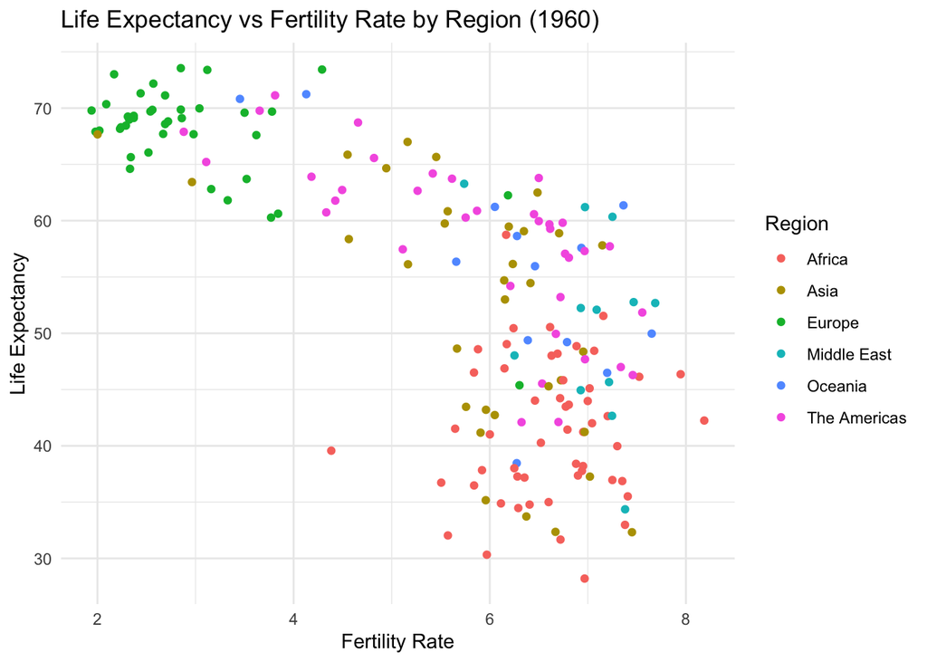

[figure not shown]

```r
# import library
library(ggplot2)

# Scatterplot for 1960
ggplot(subset(foo_merged, Year == "1960"),
       aes(x = Fertility.Rate, y = Life_Expectancy_1960, color = Region)) +
  geom_point() +
  labs(title = "Life Expectancy vs Fertility Rate by Region (1960)",
       x = "Fertility Rate",
       y = "Life Expectancy") +
  theme_minimal() +
  theme(legend.position = "right")
```

# Methodology

The data were imported and merged using R, ensuring all values for the years 1960 and 2020 were accurate and accounted for. The ‘Year’ variable was converted to a factor to facilitate clear categorization in the scatterplots. After cleaning and preparing the data, scatterplots were generated to visualize the relationship between the two variables, with color coding by region.

# Findings

## Fertility Rate

There has been a universal decline in fertility rates from 1960 to 2020. In 1960, many regions had higher fertility rates, with several countries exceeding six children per woman. By 2020, there is a significant shift towards lower fertility rates, with the majority of countries falling below three children per woman.

## Life Expectancy

Life expectancy has increased across all regions between 1960 and 2020. This improvement is particularly notable in regions that had lower life expectancies in 1960, such as Africa and Asia. By 2020, the life expectancy in these regions had risen considerably, closing the gap with Europe and The Americas.

## Regional Variance

In 1960, stark differences in life expectancy were evident between regions. By 2020, these disparities had reduced, suggesting that improvements in healthcare, education, and economic conditions have had a global impact. However, regional differences still persist, indicating that not all areas have benefited equally from these advancements.

## Outliers and Distribution

# Conclusions

The analysis of the World Bank data has revealed significant changes in fertility rates and life expectancy over the last 60 years. The global trends suggest a positive outlook with increased life expectancy and reduced fertility rates, contributing to the aging population phenomenon. The narrowed disparity between regions highlights the effectiveness of international health initiatives and economic development programs.

# Recommendations

Further investigation into the socio-economic factors influencing these trends is recommended to identify successful policies and practices. Additionally, regions with lower improvements should be analyzed to tailor interventions that address specific challenges. Lastly, as the global population ages, planning for the implications of an older demographic will become increasingly crucial for policy-makers.

# Acknowledgements

This report was made possible through the data provided by the World Bank and the diligent application of statistical analysis using R. The insights derived from this work will contribute to informed decision-making for future health and economic policies.